# Spatial Data Homework

Here is the homework for the geospatial data content.

## The Raw Data

For this homework we will continue to work with the data from Baja California on the Sonoran Desert bark beetle, *Araptus attenuatus*.

Here are the coordinates and other data for the sample sites in Baja California.

```r
beetle_url <- "https://raw.githubusercontent.com/dyerlab/ENVS-Lectures/master/data/Araptus_Disperal_Bias.csv"
```

And here are links to the rasters.

```r
precip_total_url <- "https://github.com/dyerlab/ENVS-Lectures/raw/master/data/Annual_Precip_22.tif"
minimum_precip_url <- "https://github.com/dyerlab/ENVS-Lectures/raw/master/data/Minimum_Precip_22.tif"
maximum_precip_url <- "https://github.com/dyerlab/ENVS-Lectures/raw/master/data/Maximum_Precip.tif"

minimum_temp_url <- "https://github.com/dyerlab/ENVS-Lectures/raw/master/data/Minimum_Temp_22.tif"
mean_temp_url <- "https://github.com/dyerlab/ENVS-Lectures/raw/master/data/Mean_Temp_22.tif"
maximum_temp_url <- "https://github.com/dyerlab/ENVS-Lectures/raw/master/data/Maximum_Temp_22.tif"

elevation_url <- "https://github.com/dyerlab/ENVS-Lectures/raw/master/data/alt_22.tif"
```

```r
read_csv( beetle_url ) %>%
  st_as_sf( coords=c("Longitude","Latitude"),
            crs = 4326 ) -> beetles
box <- extent( c(-115, -109, 23, 30 ) )

raster( elevation_url ) %>% crop( box ) -> elevation
raster( minimum_precip_url ) %>% crop( box ) -> precip_min
raster( precip_total_url ) %>% crop( box ) -> precip_total
raster( maximum_precip_url ) %>% crop( box ) -> precip_max
raster( minimum_temp_url ) %>% crop( box ) -> temp_min
raster( mean_temp_url ) %>% crop( box ) -> temp_mean
raster( maximum_temp_url ) %>% crop( box ) -> temp_max
```

## Questions

1. Is there any correlation between the environmental variables represented in the rasters above and the sex ratio sampled at each site? Present your results in tabular format and make appropriate caption.

```r
beetles$`Total Precipitation`     <- extract( precip_min,   as(beetles, "Spatial"))
beetles$`Minimum Precipitation`   <- extract( precip_total, as(beetles, "Spatial"))
beetles$`Maximum Precipitation`   <- extract( precip_max,   as(beetles, "Spatial"))
beetles$`Minimum Temperature`     <- extract( temp_min,     as(beetles, "Spatial"))
beetles$`Mean Temperature`        <- extract( temp_mean,    as(beetles, "Spatial"))
beetles$`Maximum Temperature`     <- extract( temp_max,     as(beetles, "Spatial"))
beetles$`Elevation`               <- extract( elevation,    as(beetles, "Spatial"))


df <- st_drop_geometry( beetles )

env.df <- data.frame( Feature = names( df[,8:14]),
                      Correlation = NA ,
                      P = NA)



cor <- cor.test(  df$MFRatio, df$`Total Precipitation` )
env.df$Correlation[ 1 ] <- cor$estimate
env.df$P[1] <- cor$p.value

cor <- cor.test(  df$MFRatio, df$`Minimum Precipitation` )
env.df$Correlation[ 2 ] <- cor$estimate
env.df$P[2] <- cor$p.value

cor <- cor.test(  df$MFRatio, df$`Maximum Precipitation` )
env.df$Correlation[ 3 ] <- cor$estimate
env.df$P[3] <- cor$p.value

cor <- cor.test(  df$MFRatio, df$`Minimum Temperature` )
env.df$Correlation[ 4 ] <- cor$estimate
env.df$P[4] <- cor$p.value

cor <- cor.test(  df$MFRatio, df$`Mean Temperature` )
env.df$Correlation[ 5 ] <- cor$estimate
env.df$P[5] <- cor$p.value

cor <- cor.test(  df$MFRatio, df$`Maximum Temperature` )
env.df$Correlation[ 6 ] <- cor$estimate
env.df$P[6] <- cor$p.value

cor <- cor.test(  df$MFRatio, df$`Elevation` )
env.df$Correlation[ 7 ] <- cor$estimate
env.df$P[7] <- cor$p.value

env.df %>%
  kable( digits = 3 ) %>%
  kableExtra::kable_minimal()
```

| Feature | Correlation | P |
| --- | --- | --- |
| Total Precipitation | -0.089 | 0.632 |
| Minimum Precipitation | 0.006 | 0.977 |
| Maximum Precipitation | 0.002 | 0.990 |
| Minimum Temperature | -0.004 | 0.982 |
| Mean Temperature | 0.116 | 0.536 |
| Maximum Temperature | 0.111 | 0.551 |
| Elevation | -0.103 | 0.580 |

2. Create a plot of all populations in the data set with the size of the plot symbol representing the sex ratio and the fill color representing the habitat suitability.

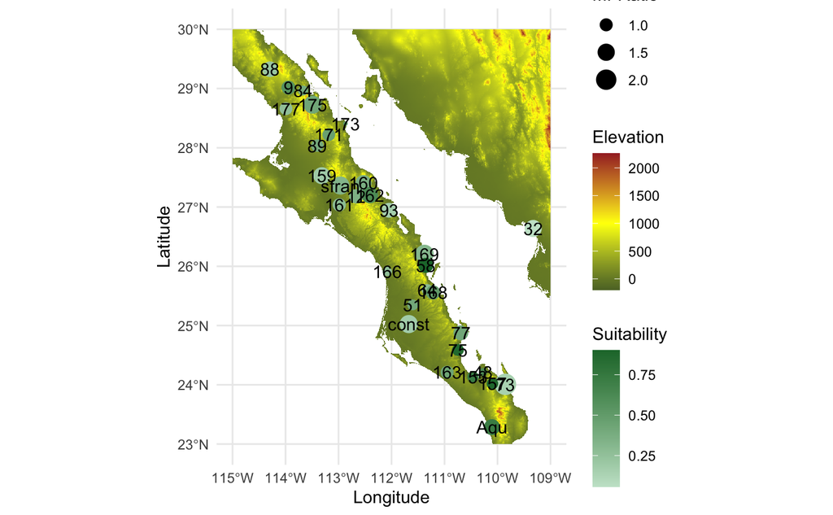

```r
elevation %>%
  rasterToPoints() %>%
  as.data.frame() %>%
  transmute( Longitude = x,
             Latitude = y,
             Elevation = alt_22 ) -> elev

ggplot() +
  geom_raster( aes(Longitude, Latitude, fill=Elevation),
               data = elev ) +
  geom_sf( aes(size=MFRatio, color=Suitability),
           data=beetles,
           pch=16) +
  geom_sf_text( aes(label=Site),
                   data = beetles )  +
  scale_fill_gradient2( low = "darkolivegreen",
                        mid = "yellow",
                        high = "brown",
                        midpoint = 1000 ) +
  scale_color_gradient( high="#1e7537",
                        low="#c7e4cf") +
  theme_minimal()
```

3. The sites in the Cape Region (that bottom part of the peninsula, are of particular interest). Contrast these sites by creating plots for all the environmental features in these “Cape” populations and compare them to the same features sampled from the remaining “Peninsular” populations. Contrast by feature.

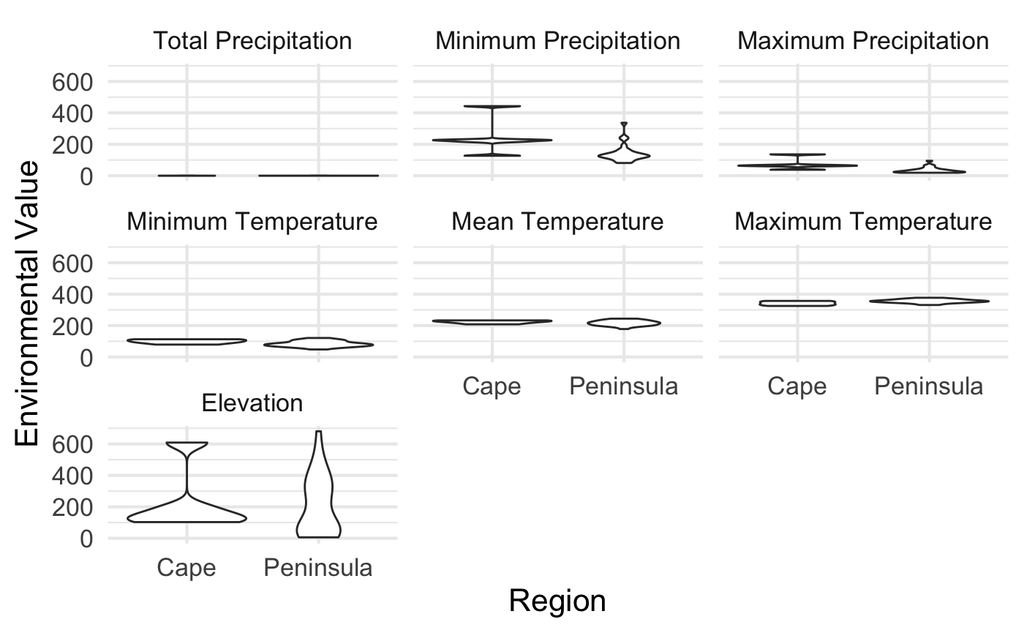

```r
cape_populations <- c("Aqu", "157", "163", "73", "48")

beetles %>%
  mutate( Region = ifelse( Site %in% cape_populations, "Cape", "Peninsula") ) -> beetles


# You can make these plots in a lot of different ways. Here they are as a grid of violin plots.
#  ggplot( beetles, aes(Region, `Maximum Precipitation`) ) + geom_violin()
# and the rest of them.

# I'm going to reshape the data frame into long format and use facet_wrap to make all the plots
library( reshape2 )
beetles[, c(1,16,9:15) ] %>%
  melt( id = c("Site","Region"),
        measure.vars = names(beetles)[9:15] ) %>%
  ggplot( aes(Region, value) ) +
    geom_violin() +
    facet_wrap(.~variable, ncol=3) +
    ylab("Environmental Value")
```

4. Crop all the rasters to show the peninsular sites between 27° and 28° North Latitude. Show a plot for each feature.

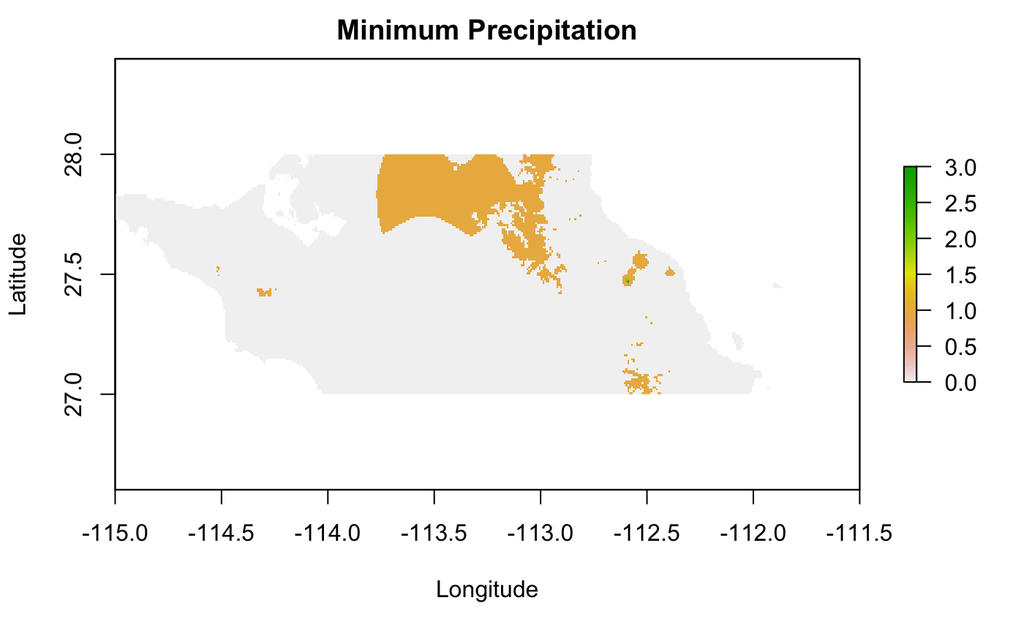

```r
north_baja <- extent( c(-115, -111.5, 27, 28 ) )

crop( precip_min, north_baja) %>%
  plot( xlab="Longitude", ylab="Latitude", main="Minimum Precipitation")
```

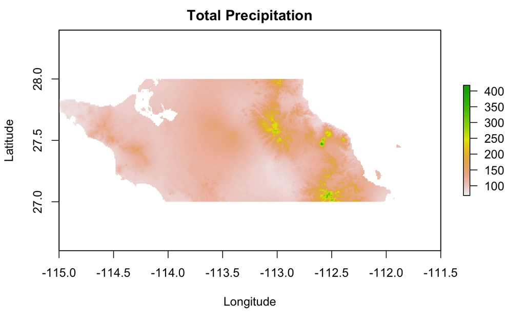

```r
crop( precip_total, north_baja) %>%
  plot( xlab="Longitude", ylab="Latitude", main="Total Precipitation")
```

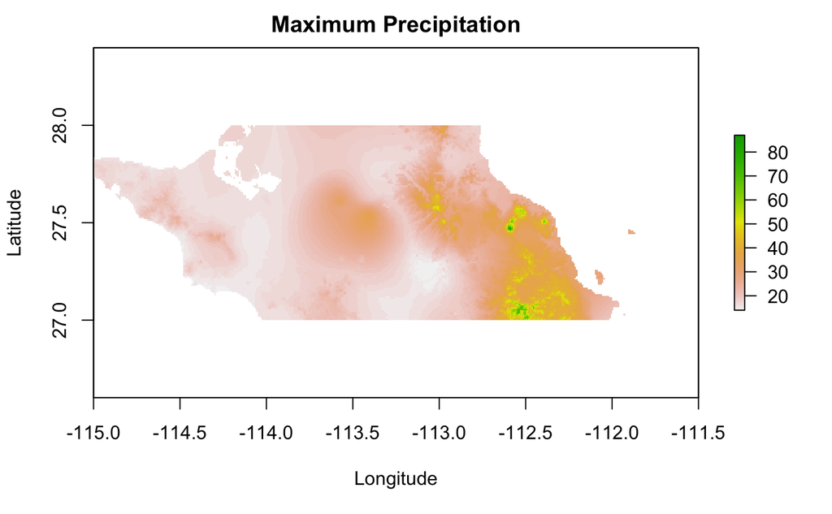

```r
crop( precip_max, north_baja) %>%
  plot( xlab="Longitude", ylab="Latitude", main="Maximum Precipitation")
```

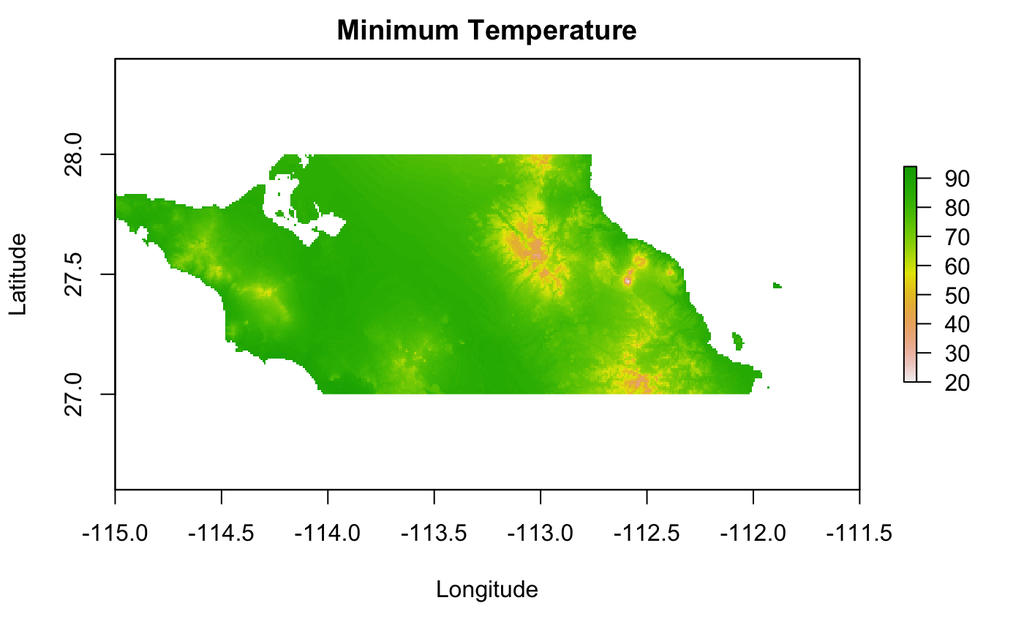

```r
crop( temp_min, north_baja) %>%
  plot( xlab="Longitude", ylab="Latitude", main="Minimum Temperature")
```

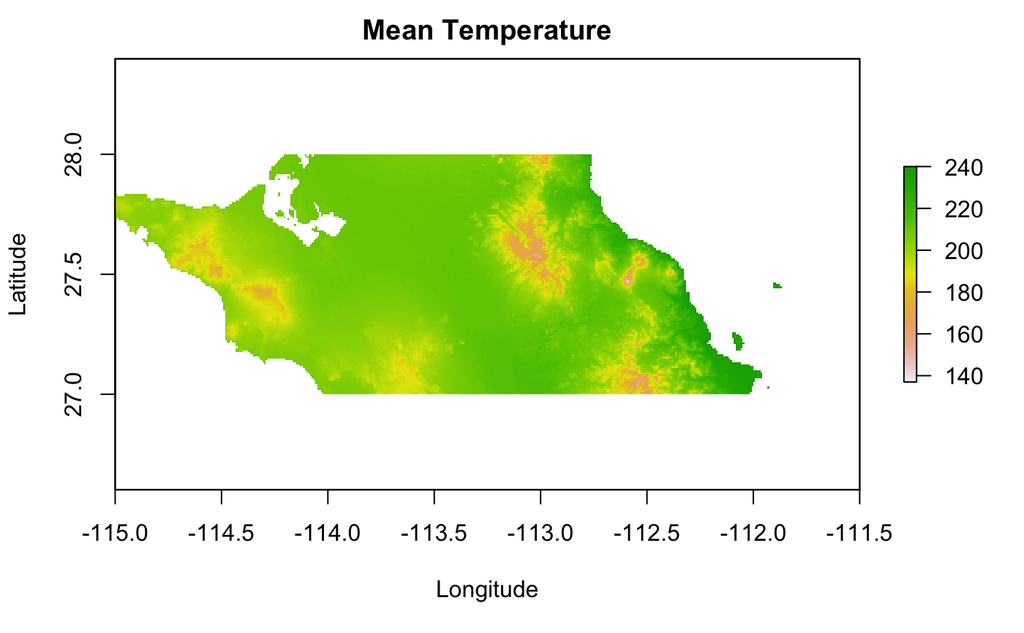

```r
crop( temp_mean, north_baja) %>%
  plot( xlab="Longitude", ylab="Latitude", main="Mean Temperature")
```

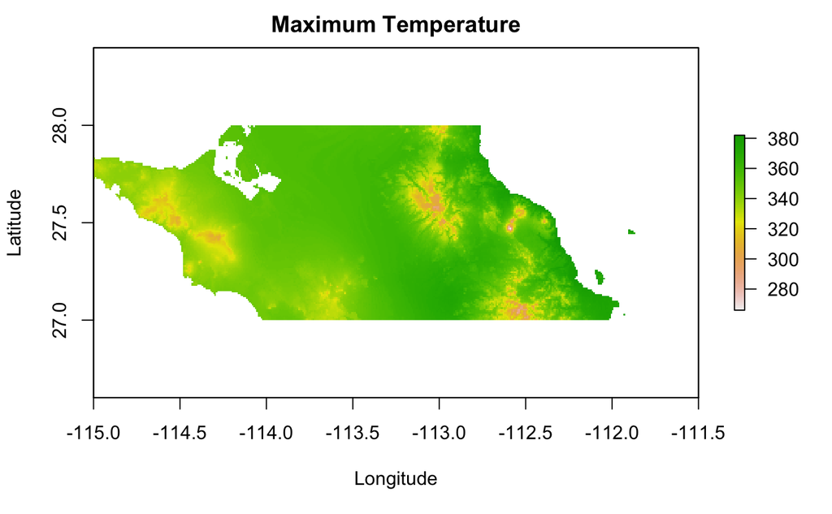

```r
crop( temp_max, north_baja) %>%
  plot( xlab="Longitude", ylab="Latitude", main="Maximum Temperature")
```

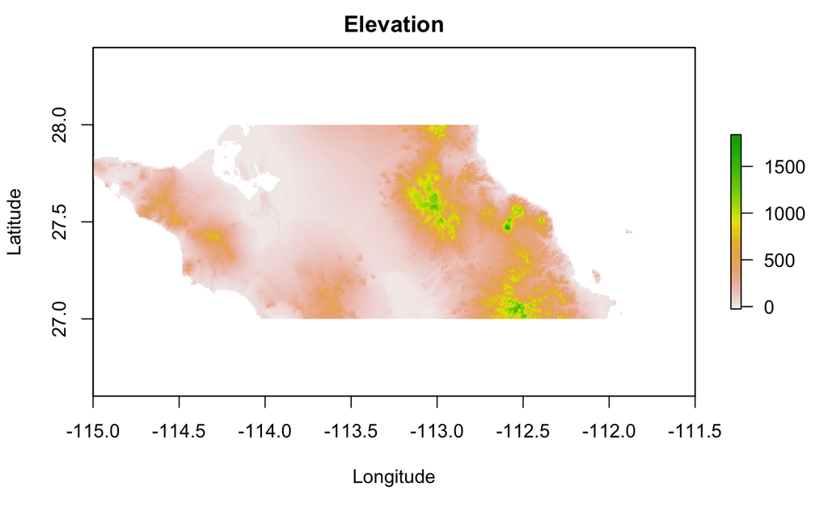

```r
crop( elevation, north_baja) %>%
  plot( xlab="Longitude", ylab="Latitude", main="Elevation")
```

5. Of all the environmental features as well as the data within the `beetles` data set, which set of predictor variables best describes the observed sex ratios? Support your argument with data, graphs, or tables.

```r
# you can use a number of ways to represent these data, I'm going to make a fancy table
df.summary <- data.frame( Variable = names( df )[c(4,6:14)] )
df.summary$Correlation <- NA
df.summary$LowerCI <- NA
df.summary$UpperCI <- NA

df.small <- as.data.frame( df[ , c(4,6:14) ] )

for( i in 1:10 ) {
  fit.cor <- cor.test( df$MFRatio, df.small[,i] )
  df.summary$Correlation[i] <- fit.cor$estimate
  df.summary$LowerCI[i] <- as.numeric( fit.cor$conf.int )[1]
  df.summary$UpperCI[i] <- as.numeric( fit.cor$conf.int )[2]
}

df.summary %>%
  dplyr::select( Variable, Correlation ) %>%
  mutate( `Confidence Interval` = "" ) %>%
  kable( digits=3 ) %>%
  kable_paper( full_width=FALSE) %>%
  column_spec( 3, image = spec_pointrange(
    x = df.summary$Correlation,
    xmin = df.summary$LowerCI,
    xmax = df.summary$UpperCI,
    vline = 0
  ))
```

| Variable | Correlation | Confidence Interval |
| --- | --- | --- |
| Suitability | -0.400 |  |
| GenVarArapat | -0.181 |  |
| GenVarEuphli | 0.066 |  |
| Total Precipitation | -0.089 |  |
| Minimum Precipitation | 0.006 |  |
| Maximum Precipitation | 0.002 |  |
| Minimum Temperature | -0.004 |  |
| Mean Temperature | 0.116 |  |
| Maximum Temperature | 0.111 |  |
| Elevation | -0.103 |  |

```r
NA
```

*I would interpret this that of all these variables, the largest correlation, and only variable with significant correlation was provided by `Suitability` (Pearson Correlation, r = -0.4, t = -2.35, df = 29, P = 0.0259). None of the other varibles were statistically larger than zero.*